# GED16/AO808: Análise de Regressão

AULA02: Prática

Ana Paula Lopes Schuch e Vinícius de Souza Lima

1o. semestre/2021

### Introdução

“[Infecção hospitalar](https://www.prefeitura.sp.gov.br/cidade/secretarias/saude/vigilancia_em_saude/infeccao_hospitalar/index.php?p=6445) é uma infecção adquirida após a admissão do paciente na unidade hospitalar e pode se manifestar durante a internação ou após a alta. Pela sua gravidade e aumento do tempo de internação do paciente, é causa importante de morbidade e mortalidade, caracterizando-se como problema de saúde pública.”

Os dados disponíveis no arquivo `data/SCENIC.txt` foram coletados pelo CDC (US Center for Disease Control), no âmbito do [Projeto SCENIC](https://doi.org/10.1093/oxfordjournals.aje.a112928). O principal objetivo do projeto era determinar se programas de vigilância e controle foram capazes de reduzir as taxas de infecção hospitalar. Os dados referem-se a uma amostra de 113 hospitais selecionados a partir de um conjunto de 338 hospitais avaliados. Cada linha do conjunto de dados contém uma identificação (1-113) e fornece informação a respeito de 11 variáveis para um único hospital. Os dados apresentados referem-se ao período de 1975-1976.

As 12 variáveis são:

1. `IDnumber`: 1-113 (identificação do hospital)
2. `LengthStay`: período de internação médio de todos os pacientes no hospital (em dias)
3. `Age`: idade média dos pacientes (anos)
4. `InfectRisk`: risco de infecção, calculado como a probabilidade média estimada de contrair infecção no hospital (em %)
5. `CultRatio`: razão do número de culturas realizadas pelo número de pacientes sem sintomas de infecção hospitalar, vezes 100
6. `XrayRatio`: razão do número de raios-X realizados pelo número de pacientes sem sintomas de pneumonia, vezes 100
7. `NBeds`: número médio de leitos do hospital, durante o período avaliado
8. `MedSchool`: afiliação a alguma Escola de Medicina (1=Sim, 2=Não)
9. `Region`: região geográfica (1=NE, 2=NC, 3=S, 4=W)
10. `DailyCensus`: número médio de pacientes no hospital por dia, durante o período avaliado
11. `NNurses`: número médio de enfermeiros no hospital
12. `Facilities`: percentual de 35 serviços providos pelo hospital

Acredita-se que o período médio de internação de um paciente `LengthStay` (variável de resposta) possa ser previsto a partir do risco de infecção hospitalar, bem como outras características do hospital e de procedimentos de rotina realizados.

### Análise Exploratória de Dados

Inicialmente, vamos preparar a massa de dados `SCENIC`, para posterior análise.

```r
# Limpa a área de trabalho
rm(list=ls())

# Carrega os dados em uma tabela
scenic <- read.table("data/SCENIC.txt", header = FALSE)
```

Algumas informações dos dados:

```r
str(scenic)
```

```
## 'data.frame':    113 obs. of  12 variables:
##  $ V1 : int  1 2 3 4 5 6 7 8 9 10 ...
##  $ V2 : num  7.13 8.82 8.34 8.95 11.2 ...
##  $ V3 : num  55.7 58.2 56.9 53.7 56.5 50.9 57.8 45.7 48.2 56.3 ...
##  $ V4 : num  4.1 1.6 2.7 5.6 5.7 5.1 4.6 5.4 4.3 6.3 ...
##  $ V5 : num  9 3.8 8.1 18.9 34.5 21.9 16.7 60.5 24.4 29.6 ...
##  $ V6 : num  39.6 51.7 74 122.8 88.9 ...
##  $ V7 : int  279 80 107 147 180 150 186 640 182 85 ...
##  $ V8 : int  2 2 2 2 2 2 2 1 2 2 ...
##  $ V9 : int  4 2 3 4 1 2 3 2 3 1 ...
##  $ V10: int  207 51 82 53 134 147 151 399 130 59 ...
##  $ V11: int  241 52 54 148 151 106 129 360 118 66 ...
##  $ V12: num  60 40 20 40 40 40 40 60 40 40 ...
```

Nomeamos as variáveis para facilitar a compreensão dos dados. Os nomes estão de acordo com o que foi descrito na seção anterior.

```r
colnames(scenic) <- c("IDnumber", "LengthStay", "Age", "InfectRisk", "CultRatio", "XrayRatio", "NBeds", "MedSchool", "Region", "DailyCensus", "NNurses", "Facilities")
```

Além disso, note que as variáveis `MedSchool` (V8) e `Region` (V9) foram categorizadas como variáveis inteiras, mas são, na verdade, categóricas. Portanto, vamos fazer a transformação das variáveis.

```r
scenic$NBeds       <- as.numeric(scenic$NBeds)
scenic$MedSchool   <- as.factor(scenic$MedSchool)
scenic$Region      <- as.factor(scenic$Region)
scenic$DailyCensus <- as.numeric(scenic$DailyCensus)
scenic$NNurses     <- as.numeric(scenic$NNurses)
```

Verificando um resumo dos dados:

```r
# Resumo das variáveis
summary(scenic)
```

```
##     IDnumber     LengthStay          Age          InfectRisk      CultRatio
##  Min.   :  1   Min.   : 6.700   Min.   :38.80   Min.   :1.300   Min.   : 1.60
##  1st Qu.: 29   1st Qu.: 8.340   1st Qu.:50.90   1st Qu.:3.700   1st Qu.: 8.40
##  Median : 57   Median : 9.420   Median :53.20   Median :4.400   Median :14.10
##  Mean   : 57   Mean   : 9.648   Mean   :53.23   Mean   :4.355   Mean   :15.79
##  3rd Qu.: 85   3rd Qu.:10.470   3rd Qu.:56.20   3rd Qu.:5.200   3rd Qu.:20.30
##  Max.   :113   Max.   :19.560   Max.   :65.90   Max.   :7.800   Max.   :60.50
##    XrayRatio          NBeds       MedSchool Region  DailyCensus
##  Min.   : 39.60   Min.   : 29.0   1:17      1:28   Min.   : 20.0
##  1st Qu.: 69.50   1st Qu.:106.0   2:96      2:32   1st Qu.: 68.0
##  Median : 82.30   Median :186.0             3:37   Median :143.0
##  Mean   : 81.63   Mean   :252.2             4:16   Mean   :191.4
##  3rd Qu.: 94.10   3rd Qu.:312.0                    3rd Qu.:252.0
##  Max.   :133.50   Max.   :835.0                    Max.   :791.0
##     NNurses        Facilities
##  Min.   : 14.0   Min.   : 5.70
##  1st Qu.: 66.0   1st Qu.:31.40
##  Median :132.0   Median :42.90
##  Mean   :173.2   Mean   :43.16
##  3rd Qu.:218.0   3rd Qu.:54.30
##  Max.   :656.0   Max.   :80.00
```

```r
# Para utilizar diretamente os nomes das variáveis
attach(scenic)
```

Vamos explorar a relação de `LengthStay` (variável de resposta) com as outras variáveis da massa de dados:

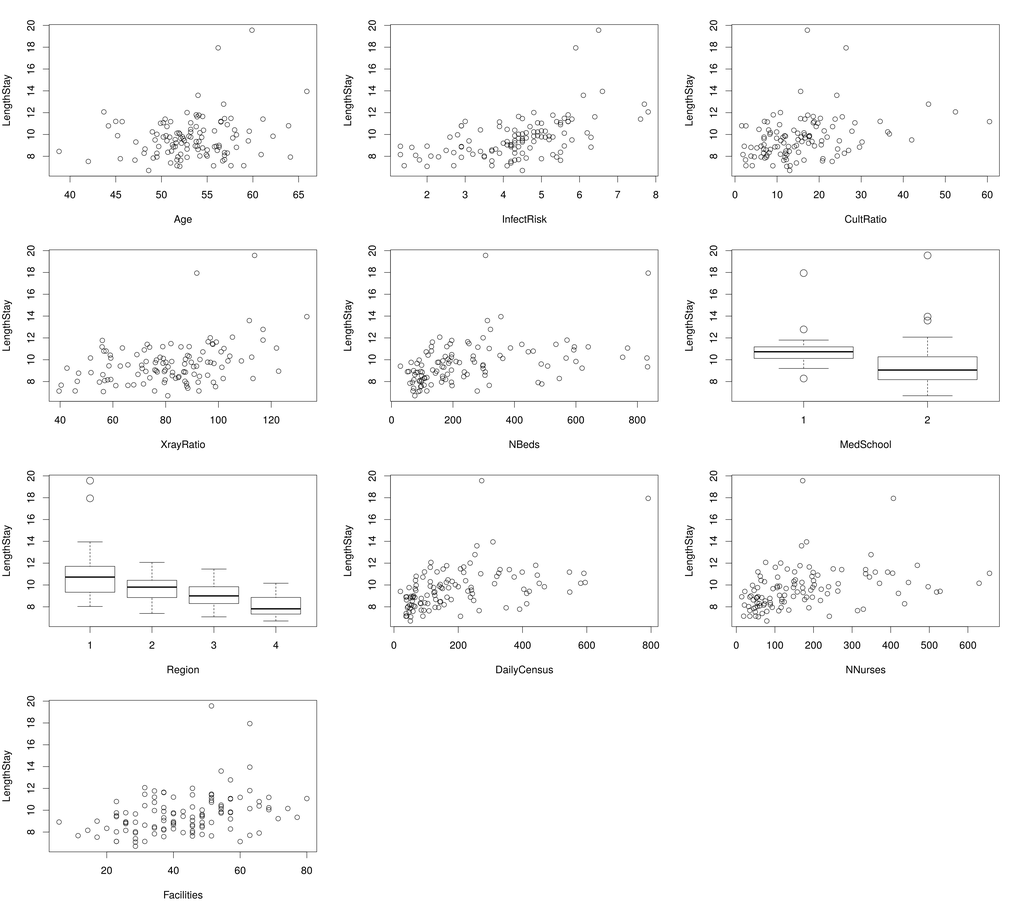

A partir desses gráficos, podemos verificar o seguinte:

- Percebemos que hospitais afiliados a alguma escola de medicina possuem tempo médio de internação maior.
- A região geográfica 1 (NE) tem maior tempo de internação, enquanto a 4 (W) tem o menor.
- Parece haver uma relação entre `LengthStay` e `InfectRisk`: conforme aumenta o risco de infecção, o tempo de permanência também tende a aumentar.
- Também parece haver uma relação entre `LengthStay` e `Facilities`: a tendência é que o tempo de permanência aumente junto com o aumento da porcentagem de serviços oferecidos pelo hospital.
- O mesmo que foi observado nos dois itens anteriores também é válido para a relação de `LengthStay` com `XrayRatio`.

### Questão 1

#### 1.1

Assumimos que o modelo de regressão linear simples é adequado para modelar a relação da variável de resposta `LengthStay` a cada uma das variáveis explicativas `InfectRisk`, `Facilities` e `XrayRatio`. Vamos construir o modelo para cada par de variáveis:

Para LengthStay e InfectRisk:

```r
stay_risk_rls <- lm(LengthStay ~ InfectRisk)
summary_risk <- summary(stay_risk_rls)
summary_risk
```

```
##
## Call:
## lm(formula = LengthStay ~ InfectRisk)
##
## Residuals:
##     Min      1Q  Median      3Q     Max
## -3.0587 -0.7776 -0.1487  0.7159  8.2805
##
## Coefficients:
##             Estimate Std. Error t value Pr(>|t|)
## (Intercept)   6.3368     0.5213  12.156  < 2e-16 ***
## InfectRisk    0.7604     0.1144   6.645 1.18e-09 ***
## ---
## Signif. codes:  0 '***' 0.001 '**' 0.01 '*' 0.05 '.' 0.1 ' ' 1
##
## Residual standard error: 1.624 on 111 degrees of freedom
## Multiple R-squared:  0.2846, Adjusted R-squared:  0.2781
## F-statistic: 44.15 on 1 and 111 DF,  p-value: 1.177e-09
```

Para LengthStay e Facilities:

```r
stay_facilities_rls <- lm(LengthStay ~ Facilities)
summary_facilities <- summary(stay_facilities_rls)
summary_facilities
```

```
##
## Call:
## lm(formula = LengthStay ~ Facilities)
##
## Residuals:
##     Min      1Q  Median      3Q     Max
## -3.2712 -1.0716 -0.2816  0.7584  9.5433
##
## Coefficients:
##             Estimate Std. Error t value Pr(>|t|)
## (Intercept)  7.71877    0.51020  15.129  < 2e-16 ***
## Facilities   0.04471    0.01116   4.008 0.000111 ***
## ---
## Signif. codes:  0 '***' 0.001 '**' 0.01 '*' 0.05 '.' 0.1 ' ' 1
##
## Residual standard error: 1.795 on 111 degrees of freedom
## Multiple R-squared:  0.1264, Adjusted R-squared:  0.1185
## F-statistic: 16.06 on 1 and 111 DF,  p-value: 0.0001113
```

Para LengthStay e XRayRatio:

```r
stay_xray_rls <- lm(LengthStay ~ XrayRatio)
summary_xray <- summary(stay_xray_rls)
summary_xray
```

```
##
## Call:
## lm(formula = LengthStay ~ XrayRatio)
##
## Residuals:
##     Min      1Q  Median      3Q     Max
## -2.9226 -1.0810 -0.2708  0.8200  8.7008
##
## Coefficients:
##             Estimate Std. Error t value Pr(>|t|)
## (Intercept) 6.566373   0.726094   9.043 5.67e-15 ***
## XrayRatio   0.037756   0.008657   4.361 2.91e-05 ***
## ---
## Signif. codes:  0 '***' 0.001 '**' 0.01 '*' 0.05 '.' 0.1 ' ' 1
##
## Residual standard error: 1.774 on 111 degrees of freedom
## Multiple R-squared:  0.1463, Adjusted R-squared:  0.1386
## F-statistic: 19.02 on 1 and 111 DF,  p-value: 2.906e-05
```

#### 1.2

Abaixo temos os gráficos de dispersão com as retas de regressão ajustadas para cada caso:

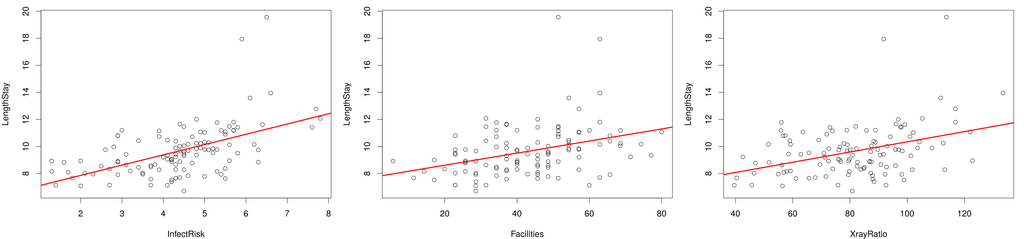

#### 1.3

Agora vamos calcular o MSE (mean square error) para cada modelo.

```r
# Cálculo do MSE para cada modelo

mse_stay_risk <- sum(stay_risk_rls$residuals**2)/(length(LengthStay)-2)
mse_stay_facilities <- sum(stay_facilities_rls$residuals**2)/(length(LengthStay)-2)
mse_stay_xray <- sum(stay_xray_rls$residuals**2)/(length(LengthStay)-2)

cat("MSE para os modelos:", "\n- LengthStay e InfectRisk: ", mse_stay_risk, "\n- LengthStay e Facilities:", mse_stay_facilities, "\n- LengthStay e XRayRatio:", mse_stay_xray)
```

```
## MSE para os modelos:
## - LengthStay e InfectRisk:  2.637518
## - LengthStay e Facilities: 3.22057
## - LengthStay e XRayRatio: 3.147261
```

Percebemos que a variável explicativa `InfectRisk` está associada ao menor MSE, então produz menor variabilidade em torno da reta de regressão ajustada.

#### 1.4

A partir do resumo de cada regressão, podemos obter os R² associados.

```r
# R² para cada modelo

cat("R² para os modelos:", "\n- LengthStay e InfectRisk: ", summary_risk$r.squared, "\n- LengthStay e Facilities:", summary_facilities$r.squared, "\n- LengthStay e XRayRatio:", summary_xray$r.squared)
```

```
## R² para os modelos:
## - LengthStay e InfectRisk:  0.2845623
## - LengthStay e Facilities: 0.1264072
## - LengthStay e XRayRatio: 0.1462924
```

Percebemos que a variável explicativa `InfectRisk` contribui para maior redução na variabilidade da resposta `LengthStay`, pois possui maior valor de R². Cerca de 28% da variação em `LengthStay` pode ser explicada utilizando a variável `InfectRisk` para prever `LengthStay` no modelo de regressão linear.

### Questão 2

#### 2.1

Queremos construir um modelo de regressão para variável resposta `LengthStay` em função de `InfectRisk` para cada região geográfica.

Para LenghtStay x InfectRisk na região NE:

```r
scenic_NE = scenic[scenic$Region == 1,]
lenght_infect_NE_rls = lm(LengthStay~InfectRisk,data = scenic_NE)
summary_ls_ir_NE = summary(lenght_infect_NE_rls)
summary_ls_ir_NE
```

```
##
## Call:
## lm(formula = LengthStay ~ InfectRisk, data = scenic_NE)
##
## Residuals:
##     Min      1Q  Median      3Q     Max
## -4.1887 -1.0713 -0.3449  0.6822  6.2617
##
## Coefficients:
##             Estimate Std. Error t value Pr(>|t|)
## (Intercept)   4.5379     1.5852   2.863 0.008193 **
## InfectRisk    1.3477     0.3159   4.267 0.000233 ***
## ---
## Signif. codes:  0 '***' 0.001 '**' 0.01 '*' 0.05 '.' 0.1 ' ' 1
##
## Residual standard error: 2.086 on 26 degrees of freedom
## Multiple R-squared:  0.4118, Adjusted R-squared:  0.3892
## F-statistic:  18.2 on 1 and 26 DF,  p-value: 0.0002326
```

Para LenghtStay x InfectRisk na região NC:

```r
scenic_NC = scenic[scenic$Region == 2,]
lenght_infect_NC_rls = lm(LengthStay~InfectRisk,data = scenic_NC)
summary_ls_ir_NC = summary(lenght_infect_NC_rls)
summary_ls_ir_NC
```

```
##
## Call:
## lm(formula = LengthStay ~ InfectRisk, data = scenic_NC)
##
## Residuals:
##     Min      1Q  Median      3Q     Max
## -2.1998 -0.6047  0.1244  0.7435  1.8283
##
## Coefficients:
##             Estimate Std. Error t value Pr(>|t|)
## (Intercept)   7.5605     0.6267  12.063 4.89e-13 ***
## InfectRisk    0.4832     0.1366   3.536  0.00134 **
## ---
## Signif. codes:  0 '***' 0.001 '**' 0.01 '*' 0.05 '.' 0.1 ' ' 1
##
## Residual standard error: 1.019 on 30 degrees of freedom
## Multiple R-squared:  0.2942, Adjusted R-squared:  0.2707
## F-statistic: 12.51 on 1 and 30 DF,  p-value: 0.001341
```

Para LenghtStay x InfectRisk na região S:

```r
scenic_S = scenic[scenic$Region == 3,]
lenght_infect_S_rls = lm(LengthStay~InfectRisk,data = scenic_S)
summary_ls_ir_S = summary(lenght_infect_S_rls)
summary_ls_ir_S
```

```
##
## Call:
## lm(formula = LengthStay ~ InfectRisk, data = scenic_S)
##
## Residuals:
##     Min      1Q  Median      3Q     Max
## -1.9748 -0.4921 -0.2071  0.2900  2.4954
##
## Coefficients:
##             Estimate Std. Error t value Pr(>|t|)
## (Intercept)   7.1293     0.4632  15.393  < 2e-16 ***
## InfectRisk    0.5251     0.1107   4.742 3.49e-05 ***
## ---
## Signif. codes:  0 '***' 0.001 '**' 0.01 '*' 0.05 '.' 0.1 ' ' 1
##
## Residual standard error: 0.9694 on 35 degrees of freedom
## Multiple R-squared:  0.3911, Adjusted R-squared:  0.3737
## F-statistic: 22.48 on 1 and 35 DF,  p-value: 3.494e-05
```

Para Lenght_Stay x InfectRisk na região W:

```r
scenic_W = scenic[scenic$Region == 4,]
lenght_infect_W_rls = lm(LengthStay~InfectRisk,data = scenic_W)
summary_ls_ir_W = summary(lenght_infect_W_rls)
summary_ls_ir_W
```

```
##
## Call:
## lm(formula = LengthStay ~ InfectRisk, data = scenic_W)
##
## Residuals:
##     Min      1Q  Median      3Q     Max
## -1.4158 -0.6716 -0.3077  0.6918  2.0425
##
## Coefficients:
##             Estimate Std. Error t value Pr(>|t|)
## (Intercept)  8.03805    1.36481   5.889 3.94e-05 ***
## InfectRisk   0.01728    0.30583   0.056    0.956
## ---
## Signif. codes:  0 '***' 0.001 '**' 0.01 '*' 0.05 '.' 0.1 ' ' 1
##
## Residual standard error: 1.038 on 14 degrees of freedom
## Multiple R-squared:  0.0002279,  Adjusted R-squared:  -0.07118
## F-statistic: 0.003192 on 1 and 14 DF,  p-value: 0.9557
```

Veja os gráficos de disperção com as retas de regressão para cada uma das regiões. Note que os limites nos eixos vertical e horizontal são os mesmos para os quatro gráficos.

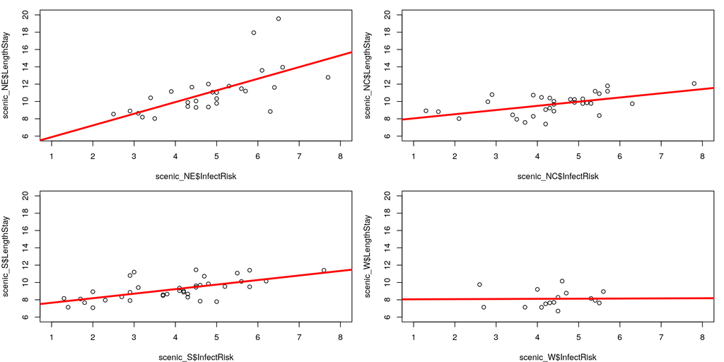

Assim, observa-se que as retas de regressão são significativamente distintas, pois enquanto na região W o coeficiente angular se aproxima de zero, é próximo de 0.50 nas regiões NC e S e superior ao dobro disso na região NE.

#### 2.2

Agora vamos calcular o MSE para cada uma das regiões:

```r
# Cálculo do MSE para cada região

mse_stay_risk_NE <- sum(lenght_infect_NE_rls$residuals**2)/(length(scenic_NE$LengthStay)-2)
mse_stay_risk_NC <- sum(lenght_infect_NC_rls$residuals**2)/(length(scenic_NC$LengthStay)-2)
mse_stay_risk_S <- sum(lenght_infect_S_rls$residuals**2)/(length(scenic_S$LengthStay)-2)
mse_stay_risk_W <- sum(lenght_infect_W_rls$residuals**2)/(length(scenic_W$LengthStay)-2)

cat("MSE para os modelos de LengthStay e InfectRisk em cada região:", "\n- NE:", mse_stay_risk_NE, "\n- NC:", mse_stay_risk_NC,"\n- S:",mse_stay_risk_S, "\n- W:", mse_stay_risk_W)
```

```
## MSE para os modelos de LengthStay e InfectRisk em cada região:
## - NE: 4.35309
## - NC: 1.037879
## - S: 0.9397947
## - W: 1.077881
```

Dessa forma percebe-se que a variabilidade em torno da reta é semelhante para as regiões NC, W e S. Já a variabilidade da região NE é substancialmente distinta das demais.

#### 2.3

Agora vamos construir intervalos de confiança 95% para os coeficientes angular das retas de regressão:

```r
# IC para os coeficientes
cat("Região NE:\n")
confint.lm(lenght_infect_NE_rls, level=0.95)

cat("\nRegião NC:\n")
confint.lm(lenght_infect_NC_rls, level=0.95)

cat("\nRegião S:\n")
confint.lm(lenght_infect_S_rls, level=0.95)

cat("\nRegião W:\n")
confint.lm(lenght_infect_W_rls, level=0.95)
```

```
## Região NE:
##                 2.5 %   97.5 %
## (Intercept) 1.2794501 7.796392
## InfectRisk  0.6984451 1.997047
##
## Região NC:
##                 2.5 %    97.5 %
## (Intercept) 6.2805261 8.8404863
## InfectRisk  0.2041384 0.7622031
##
## Região S:
##                 2.5 %   97.5 %
## (Intercept) 6.1890595 8.069615
## InfectRisk  0.3002664 0.749899
##
## Região W:
##                  2.5 %     97.5 %
## (Intercept)  5.1108117 10.9652846
## InfectRisk  -0.6386564  0.6732136
```

Assim, temos os intervalos de confiança 95% para o coeficiente angular de cada região:

- Região NE: (0.698, 1.997)
- Região NC: (0.204, 0.762)
- Região S: (0.300, 0.750)
- Região W: (-0.639, 0.673)

#### 2.4

Vamos estimar o valor médio de `LengthStay` quando `InfectRisk = 5`, para cada região.

Região NE:

```r
E_IR <- data.frame(InfectRisk = 5)
predict.lm(lenght_infect_NE_rls, newdata=E_IR, interval="confidence", level = 0.95)
```

```
##        fit      lwr      upr
## 1 11.27665 10.46114 12.09216
```

Concluímos, com 95% de confiança, que o `LengthStay` esperado para um `InfectRisk = 5` na região NE deve estar entre 10.46 e 12.09. Fazemos o mesmo para as outras 3 regiões.

```r
cat("Região NC:\n")
predict.lm(lenght_infect_NC_rls, newdata=E_IR, interval="confidence", level = 0.95)
cat("\nIntervalo: (9.57, 10.38)\n")

cat("\nRegião S:\n")
predict.lm(lenght_infect_S_rls, newdata=E_IR, interval="confidence", level = 0.95)
cat("\nIntervalo: (9.35, 10.16)\n")

cat("\nRegião W:\n")
predict.lm(lenght_infect_W_rls, newdata=E_IR, interval="confidence", level = 0.95)
cat("\nIntervalo: (7.44, 8.81)\n")
```

```
## Região NC:
##       fit      lwr     upr
## 1 9.97636 9.571522 10.3812
##
## Intervalo: (9.57, 10.38)
##
## Região S:
##        fit     lwr      upr
## 1 9.754751 9.35118 10.15832
##
## Intervalo: (9.35, 10.16)
##
## Região W:
##        fit      lwr      upr
## 1 8.124441 7.435514 8.813368
##
## Intervalo: (7.44, 8.81)
```

Espera-se que o tempo médio de estadia quando `InfectRisk = 5` seja, em média, maior na Região NE e menor na Região W, sendo intermediário nas demais regiões.

#### 2.5

Agora vamos construir intervalos de previsão, em cada região, para um novo hospital que tenha `InfectRisk = 5`.

```r
cat("Região NE:\n")
predict.lm(lenght_infect_NE_rls, newdata=E_IR, interval="prediction", level = 0.95)
cat("\nIntervalo: (6.91, 15.64)\n")

cat("\nRegião NC:\n")
predict.lm(lenght_infect_NC_rls, newdata=E_IR, interval="prediction", level = 0.95)
cat("\nIntervalo: (7.86, 12.09)\n")

cat("\nRegião S:\n")
predict.lm(lenght_infect_S_rls, newdata=E_IR, interval="prediction", level = 0.95)
cat("\nIntervalo: (7.75, 11.76)\n")

cat("\nRegião W:\n")
predict.lm(lenght_infect_W_rls, newdata=E_IR, interval="prediction", level = 0.95)
cat("\nIntervalo: (5.79, 10.45)\n")
```

```
## Região NE:
##        fit      lwr      upr
## 1 11.27665 6.911133 15.64217
##
## Intervalo: (6.91, 15.64)
##
## Região NC:
##       fit      lwr      upr
## 1 9.97636 7.856747 12.09597
##
## Intervalo: (7.86, 12.09)
##
## Região S:
##        fit      lwr      upr
## 1 9.754751 7.745751 11.76375
##
## Intervalo: (7.75, 11.76)
##
## Região W:
##        fit      lwr      upr
## 1 8.124441 5.793563 10.45532
##
## Intervalo: (5.79, 10.45)
```

Concluímos que os intervalos de previsão para `LengthStay` quando `InfectRisk = 5` de um *único* novo hospital, em todas as regiões, são mais largos que os intervalos de confiança para o `LengthStay` médio. Isso é esperado, já que o erro de prever um único valor de uma variável resposta é sempre maior do que o erro de estimar sua média.